# Machine Learning with `R`

# Regression Trees (RTREE)

# Introduction

Tree-based methods differ from regression methods because they partition the feature space into a set of rectangular regions, and then fit a simple model (like a constant) in each one. They are conceptually simple but powerful. We describe now a method for tree-based regression and classification called CART.

## `rpart` package

We now illustrate the idea behind regression trees using some data on makes of car taken from the `rpart` package. `rpart` actually calculates the mean within nodes of trees.

```r
require(rpart)
```

Let’s consider the `cu.summary` dataset (see the section *Introduction and datasets used* for further information). We first grow the tree:

```r
fit <- rpart(Mileage ~ Price + Country + Reliability + Type, method = "anova",
                         data = cu.summary)
printcp(fit)    # display the results
```

```
##
## Regression tree:
## rpart(formula = Mileage ~ Price + Country + Reliability + Type,
##     data = cu.summary, method = "anova")
##
## Variables actually used in tree construction:
## [1] Price Type
##
## Root node error: 1354.6/60 = 22.576
##
## n=60 (57 observations deleted due to missingness)
##
##         CP nsplit rel error  xerror     xstd
## 1 0.622885      0   1.00000 1.04902 0.181055
## 2 0.132061      1   0.37711 0.52379 0.103126
## 3 0.025441      2   0.24505 0.40018 0.079795
## 4 0.011604      3   0.21961 0.40523 0.076824
## 5 0.010000      4   0.20801 0.40946 0.077040
```

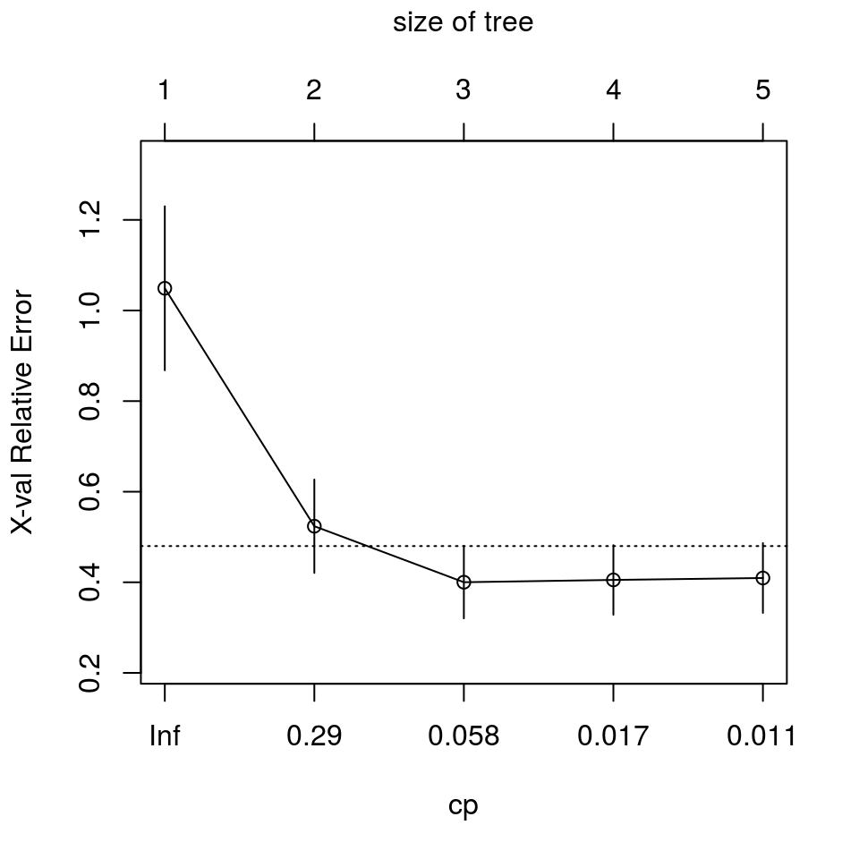

```r
plotcp(fit)     # visualize cross-validation results
```

```r
summary(fit)    # detailed summary of splits
```

```
## Call:
## rpart(formula = Mileage ~ Price + Country + Reliability + Type,
##     data = cu.summary, method = "anova")
##   n=60 (57 observations deleted due to missingness)
##
##           CP nsplit rel error    xerror       xstd
## 1 0.62288527      0 1.0000000 1.0490204 0.18105498
## 2 0.13206061      1 0.3771147 0.5237865 0.10312585
## 3 0.02544094      2 0.2450541 0.4001811 0.07979490
## 4 0.01160389      3 0.2196132 0.4052251 0.07682423
## 5 0.01000000      4 0.2080093 0.4094565 0.07704023
##
## Variable importance
##   Price    Type Country
##      48      42      10
##
## Node number 1: 60 observations,    complexity param=0.6228853
##   mean=24.58333, MSE=22.57639
##   left son=2 (48 obs) right son=3 (12 obs)
##   Primary splits:
##       Price       < 9446.5  to the right, improve=0.6228853, (0 missing)
##       Type        splits as  LLLRLL,      improve=0.5044405, (0 missing)
##       Reliability splits as  LLLRR,       improve=0.1263005, (11 missing)
##       Country     splits as  --LRLRRRLL,  improve=0.1243525, (0 missing)
##   Surrogate splits:
##       Type    splits as  LLLRLL,     agree=0.950, adj=0.750, (0 split)
##       Country splits as  --LLLLRRLL, agree=0.833, adj=0.167, (0 split)
##
## Node number 2: 48 observations,    complexity param=0.1320606
##   mean=22.70833, MSE=8.498264
##   left son=4 (23 obs) right son=5 (25 obs)
##   Primary splits:
##       Type        splits as  RLLRRL,      improve=0.43853830, (0 missing)
##       Price       < 12154.5 to the right, improve=0.25748500, (0 missing)
##       Country     splits as  --RRLRL-LL,  improve=0.13345700, (0 missing)
##       Reliability splits as  LLLRR,       improve=0.01637086, (10 missing)
##   Surrogate splits:
##       Price   < 12215.5 to the right, agree=0.812, adj=0.609, (0 split)
##       Country splits as  --RRLRL-RL,  agree=0.646, adj=0.261, (0 split)
##
```

[output cut: 21 more lines]

```
##   Surrogate splits:
##       Country splits as  --LLLL--LR, agree=0.80, adj=0.545, (0 split)
##       Type    splits as  L--RL-,     agree=0.64, adj=0.182, (0 split)
##
## Node number 8: 10 observations
##   mean=19.3, MSE=2.21
##
## Node number 9: 13 observations
##   mean=21.76923, MSE=0.7928994
##
## Node number 10: 14 observations
##   mean=23.85714, MSE=7.693878
##
## Node number 11: 11 observations
##   mean=25.45455, MSE=3.520661
```

Note: $R_{cp}(T) = R(T) + cp * |T| * R(T_0)$ i.e.: if any split does not increase the overall $R^2$ model by at least $cp$ (where $R^2$ is the usual linear-models definition) then that split is decreed to be, a priori, not worth pursuing. We can create additional plots:

```r
op <- par(mfrow = c(1, 2))
rsq.rpart(fit)
```

```
##
## Regression tree:
## rpart(formula = Mileage ~ Price + Country + Reliability + Type,
##     data = cu.summary, method = "anova")
##
## Variables actually used in tree construction:
## [1] Price Type
##
## Root node error: 1354.6/60 = 22.576
##
## n=60 (57 observations deleted due to missingness)
##
##         CP nsplit rel error  xerror     xstd
## 1 0.622885      0   1.00000 1.04902 0.181055
## 2 0.132061      1   0.37711 0.52379 0.103126
## 3 0.025441      2   0.24505 0.40018 0.079795
## 4 0.011604      3   0.21961 0.40523 0.076824
## 5 0.010000      4   0.20801 0.40946 0.077040
```

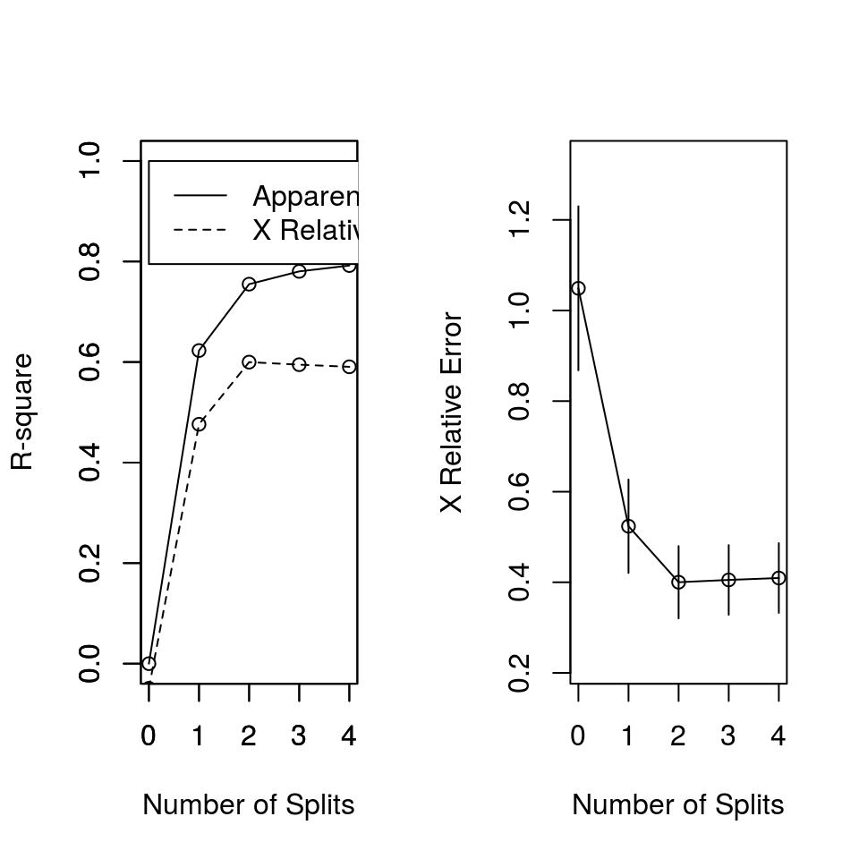

```r
par(op)
```

The X Relative Error si related to PRESS residuals.

Finally we plot the tree:

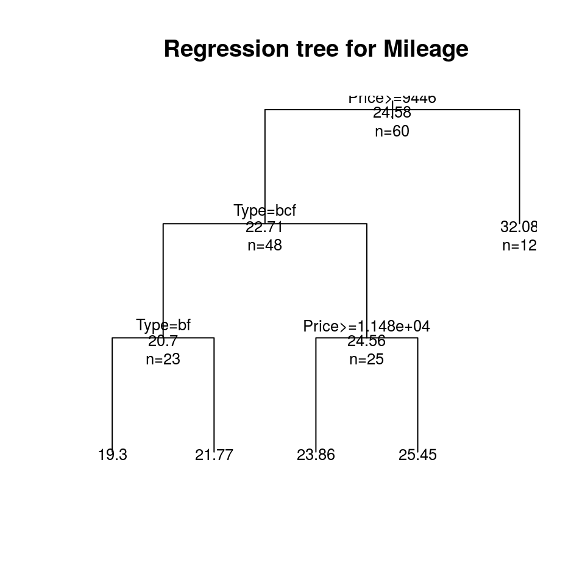

```r
plot(fit, uniform = TRUE, main = "Regression tree for Mileage")
text(fit, use.n = TRUE, all = TRUE, cex = .8)
```

We then prune the tree:

```r
pfit <- prune(fit, cp = 0.01160389) # from cptable
```

And plot the pruned tree:

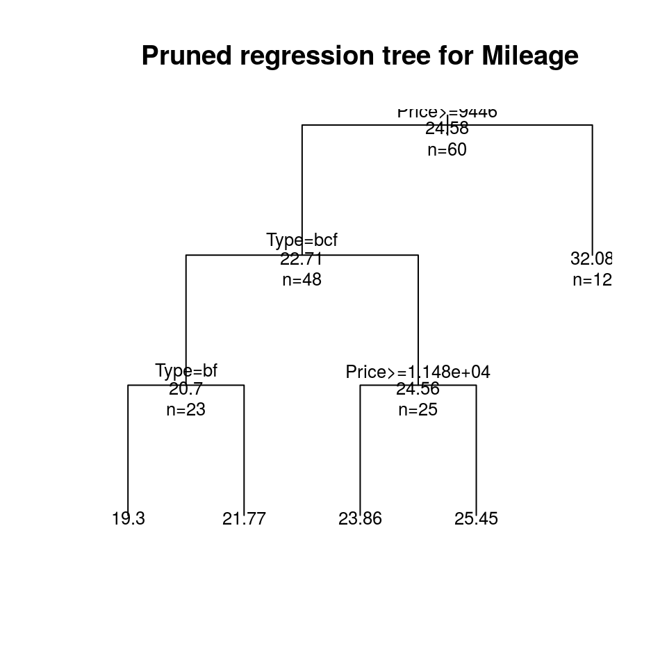

```r
plot(pfit, uniform = TRUE, main = "Pruned regression tree for Mileage")
text(pfit, use.n = TRUE, all = TRUE, cex = .8)
```

That returns the same results of non-pruned tree.

## `party` package

As a final remark, we mention the package `party`, whose `mob()` function implements a variant of the regression tree approach described so far called model-based recursive partitioning.

The `mob()` function allows one to estimate separate regression models, by splitting the data using some variables. The formula for specifying such a model is:

y ~ x1 + x2 + … + xk | z1 + … + zl,

where the variables on the left of | specify the regression variables, while those on the right of | specify the partitioning variables. The general procedure for fitting is the following:

1. Fit the model once to all observations in the current node.
2. Assess whether the parameter estimates are stable with respect to every partitioning variable z1, . . . , zl. If there is some instability, select the variable zj associated with the smallest p-value for partitioning, otherwise stop.
3. Compute the split point(s) that locally optimize an objective function.
4. Re-fit the model in both children, and repeat from step 2.

To illustrate, we consider now an example based on the well known `bostonhousing` dataset (see the section *Introduction and datasets used* for further information).

```r
bostonhousing$lstat <- log(bostonhousing$lstat)
bostonhousing$rm <- bostonhousing$rm^2
bostonhousing$chas <- factor(bostonhousing$chas, levels = 0:1, labels = c("no", "yes"))
bostonhousing$rad <- factor(bostonhousing$rad, ordered = TRUE)
```

Both the transformations only affect the parameter stability test chosen (step 2), but not the splitting procedure (step 3).

We set some control parameters for the procedure:

```r
require(party)
```

```r
ctrl <- mob_control(alpha = 0.05, bonferroni = TRUE, minsplit = 40, objfun = deviance, verbose = TRUE)
```

Then, we estimates the model:

```r
fmBH <- mob(medv ~ age + lstat + rm | zn + indus + chas + nox + age + dis + rad + tax + crim + b + ptratio, data = bostonhousing, control = ctrl, model = linearModel)
```

```
##
## -------------------------------------------
## Fluctuation tests of splitting variables:
##                     zn       indus         chas          nox          age          dis          rad
## statistic 3.915651e+01 6.48353e+01 20.144236012 9.483200e+01 3.203777e+01 6.984690e+01 1.200538e+02
## p.value   2.748895e-05 7.27457e-11  0.005144677 1.155427e-17 7.976832e-04 5.503655e-12 4.493345e-11
##                    tax         crim            b      ptratio
## statistic 9.282845e+01 8.822816e+01 3.344074e+01 7.722485e+01
## p.value   3.329097e-17 3.759587e-16 4.150856e-04 1.195801e-13
##
## Best splitting variable: nox
## Perform split? yes
## -------------------------------------------
##
## Node properties:
## nox <= 0.597; criterion = 1, statistic = 120.054
##
## -------------------------------------------
## Fluctuation tests of splitting variables:
##                    zn        indus       chas          nox         age          dis          rad
## statistic 22.16164033 38.155039447 13.1622614 3.613344e+01 21.19908930 4.984273e+01 7.873614e+01
## p.value    0.06002158  0.000042868  0.1097181 1.119481e-04  0.08950553 1.439457e-07 8.981811e-05
##                    tax         crim          b      ptratio
## statistic 5.664802e+01 3.832894e+01 16.1842317 4.680235e+01
## p.value   4.795733e-09 3.945393e-05  0.4811923 6.464767e-07
##
## Best splitting variable: tax
## Perform split? yes
## -------------------------------------------
##
## Node properties:
## tax <= 265; criterion = 1, statistic = 78.736
##
## -------------------------------------------
## Fluctuation tests of splitting variables:
##                  zn      indus      chas       nox       age       dis        rad       tax        crim
## statistic 3.3545026 10.0069447 5.7151219 3.1451982 7.9081059 7.8745370 26.9826810 5.0300885 16.99327331
## p.value   0.9999773  0.5514421 0.9363047 0.9999919 0.8314404 0.8352436  0.7990803 0.9953639  0.05201363
##                   b    ptratio
## statistic 5.7652226 14.0764807
```

[output cut: 94 more lines]

```
## p.value   0.9644422 0.9990245  0.1192863  0.02992438 1.00000 0.9998421  0.0265835  0.04739517  0.05091238
##                    b    ptratio
## statistic 12.7217188 17.7130063
## p.value    0.6560969  0.1498435
##
## Best splitting variable: rad
## Perform split? yes
## -------------------------------------------
##
## Splitting ordered factor variable, objective function:
##        1        2        3        4        5        6        7        8
##      Inf      Inf      Inf      Inf 875.6391 875.6391 875.6391 875.6391
##
## Node properties:
## rad <= 5; criterion = 0.973, statistic = 23.862
```

```r
fmBH
```

```
## 1) nox <= 0.597; criterion = 1, statistic = 120.054
##   2) tax <= 265; criterion = 1, statistic = 78.736
##     3)*  weights = 82
## Terminal node model
## Linear model with coefficients:
## (Intercept)          age        lstat           rm
##    -2.23429      0.02483     -3.01289      0.81660
##
##   2) tax > 265
##     4) rad <= 4; criterion = 1, statistic = 91.223
##       5)*  weights = 111
## Terminal node model
## Linear model with coefficients:
## (Intercept)          age        lstat           rm
##    -3.43902     -0.07993      1.06950      0.70388
##
##     4) rad > 4
##       6) ptratio <= 17.4; criterion = 0.993, statistic = 29.951
##         7)*  weights = 57
## Terminal node model
## Linear model with coefficients:
## (Intercept)          age        lstat           rm
##    7.731363    -0.006482    -2.864374     0.585465
##
##       6) ptratio > 17.4
##         8)*  weights = 91
## Terminal node model
## Linear model with coefficients:
## (Intercept)          age        lstat           rm
##     12.2025      -0.0687      -0.6483       0.3870
##
## 1) nox > 0.597
##   9) dis <= 1.6074; criterion = 1, statistic = 34.99
##     10)*  weights = 40
## Terminal node model
## Linear model with coefficients:
## (Intercept)          age        lstat           rm
##     97.1330      -0.1065     -20.6139      -0.2542
##
##   9) dis > 1.6074
##     11) rad <= 5; criterion = 0.973, statistic = 23.862
##       12)*  weights = 50
## Terminal node model
## Linear model with coefficients:
## (Intercept)          age        lstat           rm
##     38.3059      -0.1677      -9.2983       0.5834
##
##     11) rad > 5
##       13)*  weights = 75
## Terminal node model
## Linear model with coefficients:
## (Intercept)          age        lstat           rm
##    61.34934     -0.09697    -12.19267     -0.06927
```

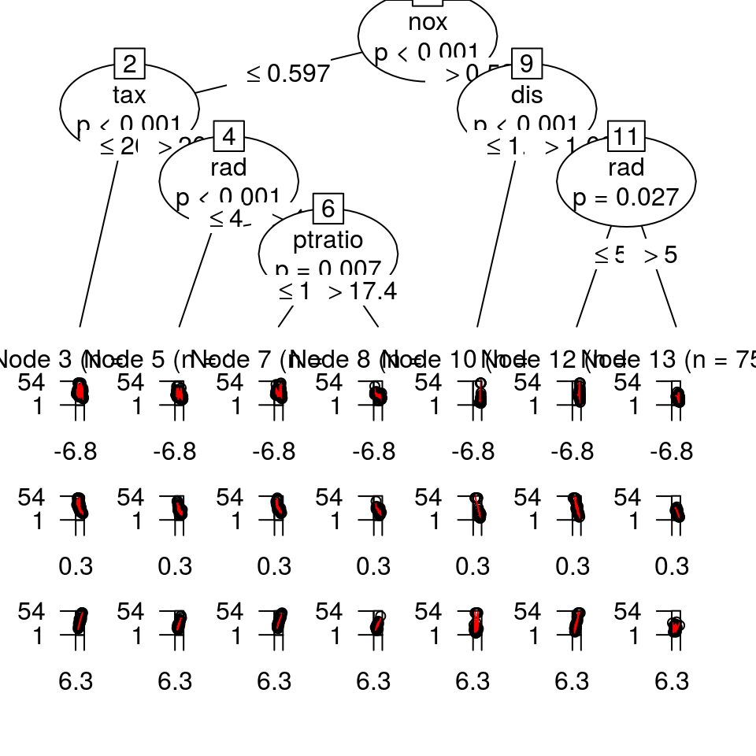

```r
plot(fmBH)
```

```r
coef(fmBH)
```

```
##    (Intercept)          age       lstat          rm
## 3    -2.234289  0.024827161  -3.0128873  0.81659999
## 5    -3.439016 -0.079931189   1.0695002  0.70387750
## 7     7.731363 -0.006482131  -2.8643737  0.58546514
## 8    12.202515 -0.068697423  -0.6483409  0.38703319
## 10   97.133016 -0.106517216 -20.6139361 -0.25421913
## 12   38.305900 -0.167657196  -9.2983159  0.58342155
## 13   61.349342 -0.096967406 -12.1926707 -0.06926919
```

```r
summary(fmBH)
```

```
## $`3`
##
## Call:
## NULL
##
## Weighted Residuals:
##    Min     1Q Median     3Q    Max
## -6.479  0.000  0.000  0.000 12.831
##
## Coefficients:
##             Estimate Std. Error t value Pr(>|t|)
## (Intercept) -2.23429    4.26921  -0.523   0.6022
## age          0.02483    0.01983   1.252   0.2143
## lstat       -3.01289    1.16980  -2.576   0.0119 *
## rm           0.81660    0.06168  13.240   <2e-16 ***
## ---
## Signif. codes:  0 '***' 0.001 '**' 0.01 '*' 0.05 '.' 0.1 ' ' 1
##
## Residual standard error: 3.18 on 78 degrees of freedom
## Multiple R-squared:  0.8893, Adjusted R-squared:  0.885
## F-statistic: 208.8 on 3 and 78 DF,  p-value: < 2.2e-16
##
##
## $`5`
##
## Call:
## NULL
##
## Weighted Residuals:
##    Min     1Q Median     3Q    Max
## -7.703  0.000  0.000  0.000  7.973
##
## Coefficients:
##             Estimate Std. Error t value Pr(>|t|)
## (Intercept) -3.43902    3.75219  -0.917    0.361
## age         -0.07993    0.01137  -7.030 2.02e-10 ***
## lstat        1.06950    0.94523   1.131    0.260
## rm           0.70388    0.05563  12.652  < 2e-16 ***
## ---
## Signif. codes:  0 '***' 0.001 '**' 0.01 '*' 0.05 '.' 0.1 ' ' 1
```

[output cut: 104 more lines]

```
##    Min     1Q Median     3Q    Max
## -7.532  0.000  0.000  0.000  8.328
##
## Coefficients:
##              Estimate Std. Error t value Pr(>|t|)
## (Intercept)  61.34934    4.67059  13.135  < 2e-16 ***
## age          -0.09697    0.04014  -2.416   0.0183 *
## lstat       -12.19267    1.15276 -10.577  3.1e-16 ***
## rm           -0.06927    0.04454  -1.555   0.1243
## ---
## Signif. codes:  0 '***' 0.001 '**' 0.01 '*' 0.05 '.' 0.1 ' ' 1
##
## Residual standard error: 2.894 on 71 degrees of freedom
## Multiple R-squared:  0.6859, Adjusted R-squared:  0.6727
## F-statistic: 51.69 on 3 and 71 DF,  p-value: < 2.2e-16
```

For summarizing the quality of the fit, we compute the mean squared error, the log-likelihood and the AIC index:

```r
mean(residuals(fmBH)^2)
```

```
## [1] 9.664305
```

```r
logLik(fmBH)
```

```
## 'log Lik.' -1255.384 (df=41)
```

```r
AIC(fmBH)
```

```
## [1] 2592.768
```